# Intermediate Statistics using R - Part 2

## 0. Preliminary Steps

### Set working directory

From the RStudio menu, **Session** >> **Set working Directory** >> **Choose Directory** >> Navigate to the directory where you’ve saved the data files to work with >> **Open**.

```r
### Check current working directory
getwd()
```

```
## [1] "C:/Users/Jason Lee/OneDrive - Texas Tech University/files/ttu/education/classes/stats_soft/module/r"
```

### Set the ‘Cloud’ mirror as a default CRAN (Comprehensive R Archive Network) repository

CRAN is a global network of web servers that store identical, up-to-date versions of code and documentation for R.

```r
options(repos="https://cloud.r-project.org")
```

## 1. Correlation

### Data

- **Exam Anxiety.sav**
- A psychologist is exploring the impact of exam stress and study time on test results.
- She developed an instrument to gauge exam-related stress, named the Exam Anxiety Questionnaire.
- The level of anxiety was assessed prior to the students’ exams, and their performance was evaluated based on their percentage score.

```r
### Read the SPSS data
# install.packages("haven")
library(haven)
```

```r
ExamAnxiety <- read_spss(file = 'Exam Anxiety.sav')
head(ExamAnxiety)
```

```
## # A tibble: 6 × 5
##    Code Revise  Exam Anxiety Sex
##   <dbl>  <dbl> <dbl>   <dbl> <dbl+lbl>
## 1     1      4    40    86.3 1 [Male]
## 2     2     11    65    88.7 2 [Female]
## 3     3     27    80    70.2 1 [Male]
## 4     4     53    80    61.3 1 [Male]
## 5     5      4    40    89.5 1 [Male]
## 6     6     22    70    60.5 2 [Female]
```

### For Two Variables

```r
out1 <- cor.test(ExamAnxiety$Exam, ExamAnxiety$Anxiety, method = "pearson")
out1
```

```
##
##  Pearson's product-moment correlation
##
## data:  ExamAnxiety$Exam and ExamAnxiety$Anxiety
## t = -4.938, df = 101, p-value = 3.128e-06
## alternative hypothesis: true correlation is not equal to 0
## 95 percent confidence interval:
##  -0.5846244 -0.2705591
## sample estimates:
##        cor
## -0.4409934
```

If you want to compute Spearman’s rank correlation instead of Pearson correlation, use the argument `method = "spearman"`. If you want to compute Kendall’s tau correlation, use the argument `method = "kendall"`.

The `report()` function from the `{report}` package can assist us in interpreting the analysis results.

```r
# install.packages("report")
library(report)
```

```r
report(out1)
```

```
## Effect sizes were labelled following Funder's (2019) recommendations.
##
## The Pearson's product-moment correlation between ExamAnxiety$Exam and
## ExamAnxiety$Anxiety is negative, statistically significant, and very large (r =
## -0.44, 95% CI [-0.58, -0.27], t(101) = -4.94, p < .001)
```

Note that the `report()` function can be used for various other analyses as well. For additional examples, please refer to the [documentation](https://easystats.github.io/report) provided by the package.

### For Several Pairs of Variables

```r
# install.packages("Hmisc")
library(Hmisc)
```

The `rcorr()` function from the `{Hmisc}` package allows to compute correlations and their p values for several pairs of variables at once. However, the `rcorr()` function accepts only matrices as input data. Thus, to analyze data in a data frame format, it is necessary to convert the data frame into a matrix using the `as.matrix()` function.

```r
ExamAnxietyMat <- as.matrix(ExamAnxiety[, c('Revise', 'Exam', 'Anxiety')])
out2 <- rcorr(ExamAnxietyMat)
out2
```

```
##         Revise  Exam Anxiety
## Revise    1.00  0.40   -0.71
## Exam      0.40  1.00   -0.44
## Anxiety  -0.71 -0.44    1.00
##
## n= 103
##
##
## P
##         Revise Exam Anxiety
## Revise          0    0
## Exam     0           0
## Anxiety  0      0
```

```r
### Display p values up to 6 decimals
attributes(out2) ### out2 contains 3 lists: r, n, P
```

```
## $names
## [1] "r" "n" "P"
##
## $class
## [1] "rcorr"
```

```r
round(out2$P, 6)
```

```
##          Revise    Exam Anxiety
## Revise       NA 3.3e-05   0e+00
## Exam    3.3e-05      NA   3e-06
## Anxiety 0.0e+00 3.0e-06      NA
```

```r
### Turn off scientific notation
options(scipen=999)
round(out2$P, 6)
```

```
##           Revise     Exam  Anxiety
## Revise        NA 0.000033 0.000000
## Exam    0.000033       NA 0.000003
## Anxiety 0.000000 0.000003       NA
```

### Visualization

The following figure, commonly referred to as a *correlogram*, visualizes the correlations and is created using the `corrplot` function from the `{corrplot}` [package](https://cran.r-project.org/web/packages/corrplot/vignettes/corrplot-intro.html).

```r
# install.packages("corrplot")
library(corrplot)
```

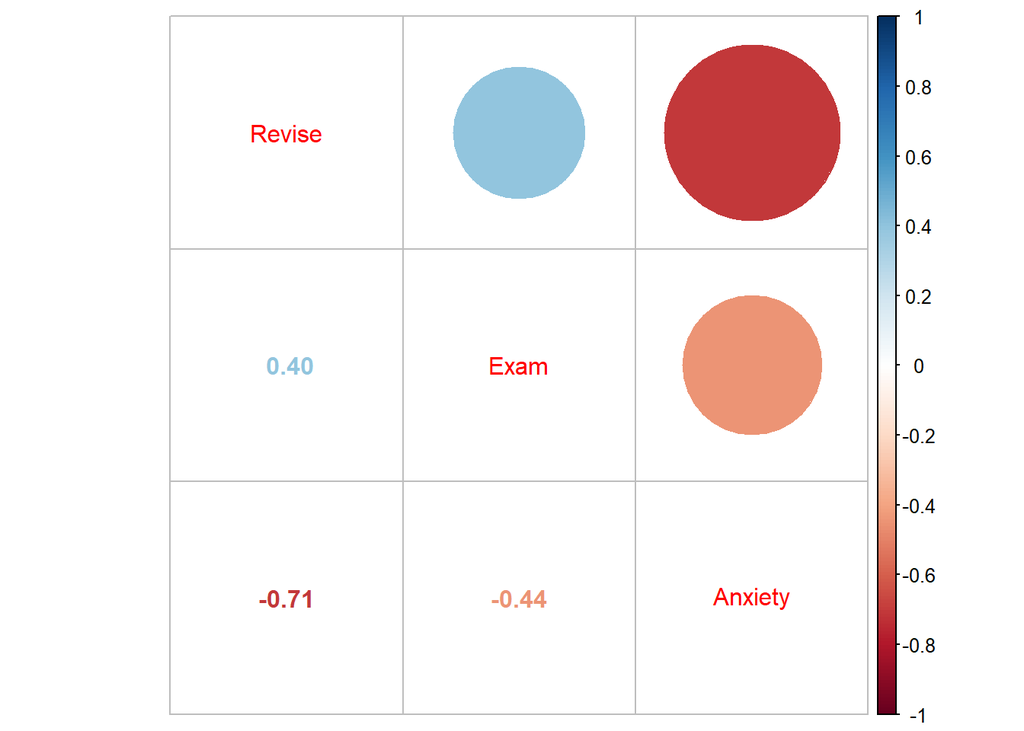

```r
corrplot.mixed(out2$r)
```

For those of you who are still not completely satisfied, consider the `ggpairs()` function from the `{GGally}` package.

```r
# install.packages("GGally")
library(GGally)
```

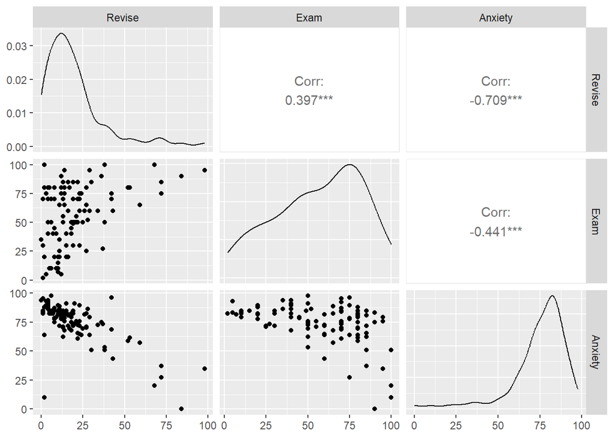

```r
ggpairs(ExamAnxiety[, c('Revise', 'Exam', 'Anxiety')])
```

The plot above combines correlation coefficients, correlation tests (via the asterisks next to the coefficients), and scatter plots for all possible pairs of the variables specified.

## 2. Linear Regression

### Data

- **Album Sales.sav**
- This data has 200 rows, with each row corresponding to a unique album.
- Two variables are presented. One reflects the pre-release promotional expenditure for the album in pounds (Adverts), and the other represents the album sales in thousands after release (Sales).

```r
### Read the SPSS data
AlbumSales <- read_spss(file = 'Album Sales.sav')
head(AlbumSales)
```

### Fit Models and Interpret Results

The `lm()` function is commonly employed for conducting linear regression. Once a regression model is fitted, you can utilize the `report()` function to obtain a “suggested” interpretation of the modeling results.

```r
out1 <- lm(Sales ~ Adverts, data = AlbumSales)
summary(out1)
```

```
##
## Call:
## lm(formula = Sales ~ Adverts, data = AlbumSales)
##
## Residuals:
##      Min       1Q   Median       3Q      Max
## -152.949  -43.796   -0.393   37.040  211.866
##
## Coefficients:
##               Estimate Std. Error t value            Pr(>|t|)
## (Intercept) 134.139938   7.536575  17.799 <0.0000000000000002 ***
## Adverts       0.096124   0.009632   9.979 <0.0000000000000002 ***
## ---
## Signif. codes:  0 '***' 0.001 '**' 0.01 '*' 0.05 '.' 0.1 ' ' 1
##
## Residual standard error: 65.99 on 198 degrees of freedom
## Multiple R-squared:  0.3346, Adjusted R-squared:  0.3313
## F-statistic: 99.59 on 1 and 198 DF,  p-value: < 0.00000000000000022
```

```r
report(out1)
```

```
## We fitted a linear model (estimated using OLS) to predict Sales with Adverts
## (formula: Sales ~ Adverts). The model explains a statistically significant and
## substantial proportion of variance (R2 = 0.33, F(1, 198) = 99.59, p < .001,
## adj. R2 = 0.33). The model's intercept, corresponding to Adverts = 0, is at
## 134.14 (95% CI [119.28, 149.00], t(198) = 17.80, p < .001). Within this model:
##
##   - The effect of Adverts is statistically significant and positive (beta = 0.10,
## 95% CI [0.08, 0.12], t(198) = 9.98, p < .001; Std. beta = 0.58, 95% CI [0.46,
## 0.69])
##
## Standardized parameters were obtained by fitting the model on a standardized
## version of the dataset. 95% Confidence Intervals (CIs) and p-values were
## computed using a Wald t-distribution approximation.
```

### Check Model Assumptions and Performance

The `{performance}` [package](https://easystats.github.io/performance) offers a variety of functions to assess model assumptions. To perform a comprehensive check, use the `check_model()` function.

```r
# install.packages("performance", dependencies = TRUE) ### Install all dependencies
library(performance)
```

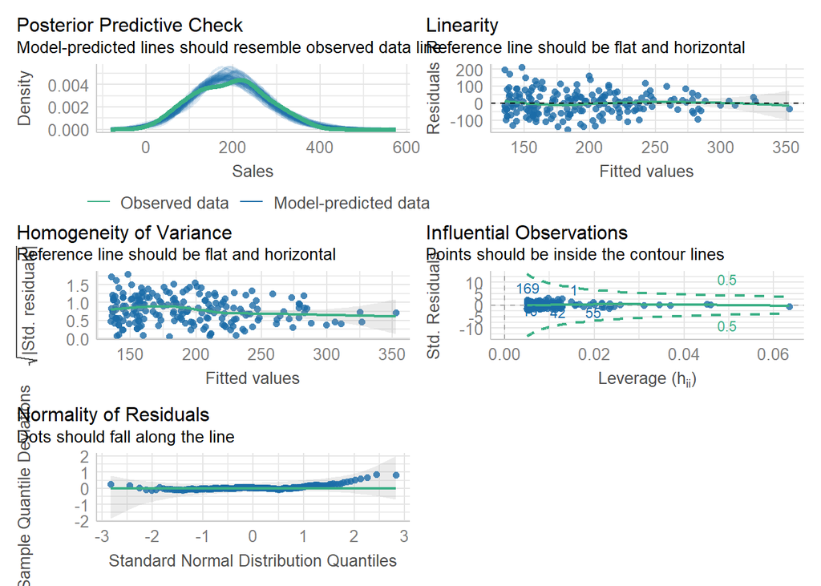

```r
# update.packages("patchwork") ### Update the 'patchwork' package when a 'too-small-window' error occurs
check_model(out1)
```

If high leverage points exist (i.e., points located outside of the contour lines in the Influential Observation plot), it is recommended to remove them, as they can potentially distort predictions.

The `check_heteroscedasticity()` function evaluates whether *homoscedasticity* has been violated.

```r
check_heteroscedasticity(out1)
```

[output not shown]

The `model_performance()` function calculates performance indices for a model. Depending on the model object, typical indices may include r-squared, **AIC**, **BIC**, **RMSE**, or **ICC**.

```r
model_performance(out1)
```

```
## # Indices of model performance
##
## AIC      |     AICc |      BIC |    R2 | R2 (adj.) |   RMSE |  Sigma
## --------------------------------------------------------------------
## 2247.375 | 2247.498 | 2257.270 | 0.335 |     0.331 | 65.661 | 65.991
```

*[Note]* AIC and BIC are information criteria for comparing models. Each tries to balance model fit and parsimony and each penalizes differently for number of parameters. A lower AIC or BIC value indicates a better fit.

Root mean square error (RMSE) measures the average difference between a model’s predicted values and the actual values (the data). Mathematically, it is the standard deviation of the residuals. Residuals represent the distance between the regression line and the data points.

Sigma is the “estimated” standard deviation of the residuals.

## 3. Linear Multiple Regression

### Data

- **Album Sales.sav**
- In the previous example, the executive determined that the advertising budget significantly predicts album sales, hence, this variable should be the first inclusion in the model.
- Two additional variables should be taken into account: the number of radio plays before the album’s release (Airplay) and the band’s attractiveness (Image).
- These new variables would be introduced into the model subsequent to the advertising budget. This hierarchical method allows the researcher to determine the order of variable entry into the model, guided by previous research.
- It is necessary to introduce variables in blocks, with each block representing a different step in the hierarchical sequence.

```r
### Read the SPSS data
AlbumSales <- read_spss(file = 'Album Sales.sav')
head(AlbumSales)
```

### Fit Models and Interpret Results

We will fit three models, each with a different set of predictor variables.

```r
out1 <- lm(Sales ~ Adverts, data = AlbumSales)

out2 <- lm(Sales ~ Adverts + Image, data = AlbumSales)

out3 <- lm(Sales ~ Adverts + Image + Airplay, data = AlbumSales)
summary(out3)
```

```
##
## Call:
## lm(formula = Sales ~ Adverts + Image + Airplay, data = AlbumSales)
##
## Residuals:
##      Min       1Q   Median       3Q      Max
## -121.324  -28.336   -0.451   28.967  144.132
##
## Coefficients:
##               Estimate Std. Error t value             Pr(>|t|)
## (Intercept) -26.612958  17.350001  -1.534                0.127
## Adverts       0.084885   0.006923  12.261 < 0.0000000000000002 ***
## Image        11.086335   2.437849   4.548           0.00000949 ***
## Airplay       3.367425   0.277771  12.123 < 0.0000000000000002 ***
## ---
## Signif. codes:  0 '***' 0.001 '**' 0.01 '*' 0.05 '.' 0.1 ' ' 1
##
## Residual standard error: 47.09 on 196 degrees of freedom
## Multiple R-squared:  0.6647, Adjusted R-squared:  0.6595
## F-statistic: 129.5 on 3 and 196 DF,  p-value: < 0.00000000000000022
```

```r
report(out3)
```

```
## We fitted a linear model (estimated using OLS) to predict Sales with Adverts,
## Image and Airplay (formula: Sales ~ Adverts + Image + Airplay). The model
## explains a statistically significant and substantial proportion of variance (R2
## = 0.66, F(3, 196) = 129.50, p < .001, adj. R2 = 0.66). The model's intercept,
## corresponding to Adverts = 0, Image = 0 and Airplay = 0, is at -26.61 (95% CI
## [-60.83, 7.60], t(196) = -1.53, p = 0.127). Within this model:
##
##   - The effect of Adverts is statistically significant and positive (beta = 0.08,
## 95% CI [0.07, 0.10], t(196) = 12.26, p < .001; Std. beta = 0.51, 95% CI [0.43,
## 0.59])
##   - The effect of Image is statistically significant and positive (beta = 11.09,
## 95% CI [6.28, 15.89], t(196) = 4.55, p < .001; Std. beta = 0.19, 95% CI [0.11,
## 0.27])
##   - The effect of Airplay is statistically significant and positive (beta = 3.37,
## 95% CI [2.82, 3.92], t(196) = 12.12, p < .001; Std. beta = 0.51, 95% CI [0.43,
## 0.60])
##
## Standardized parameters were obtained by fitting the model on a standardized
## version of the dataset. 95% Confidence Intervals (CIs) and p-values were
## computed using a Wald t-distribution approximation.
```

### Compare Models

The `compare_performance()` function from the `{performance}` assesses and compares the performance and quality of multiple models.

```r
compare_performance(out1, out2, out3)
```

```
## # Comparison of Model Performance Indices
##
## Name | Model |  AIC (weights) | AICc (weights) |  BIC (weights) |    R2 | R2 (adj.) |   RMSE |  Sigma
## -----------------------------------------------------------------------------------------------------
## out1 |    lm | 2247.4 (<.001) | 2247.5 (<.001) | 2257.3 (<.001) | 0.335 |     0.331 | 65.661 | 65.991
## out2 |    lm | 2224.2 (<.001) | 2224.4 (<.001) | 2237.4 (<.001) | 0.413 |     0.407 | 61.662 | 62.129
## out3 |    lm | 2114.3 (>.999) | 2114.6 (>.999) | 2130.8 (>.999) | 0.665 |     0.660 | 46.614 | 47.087
```

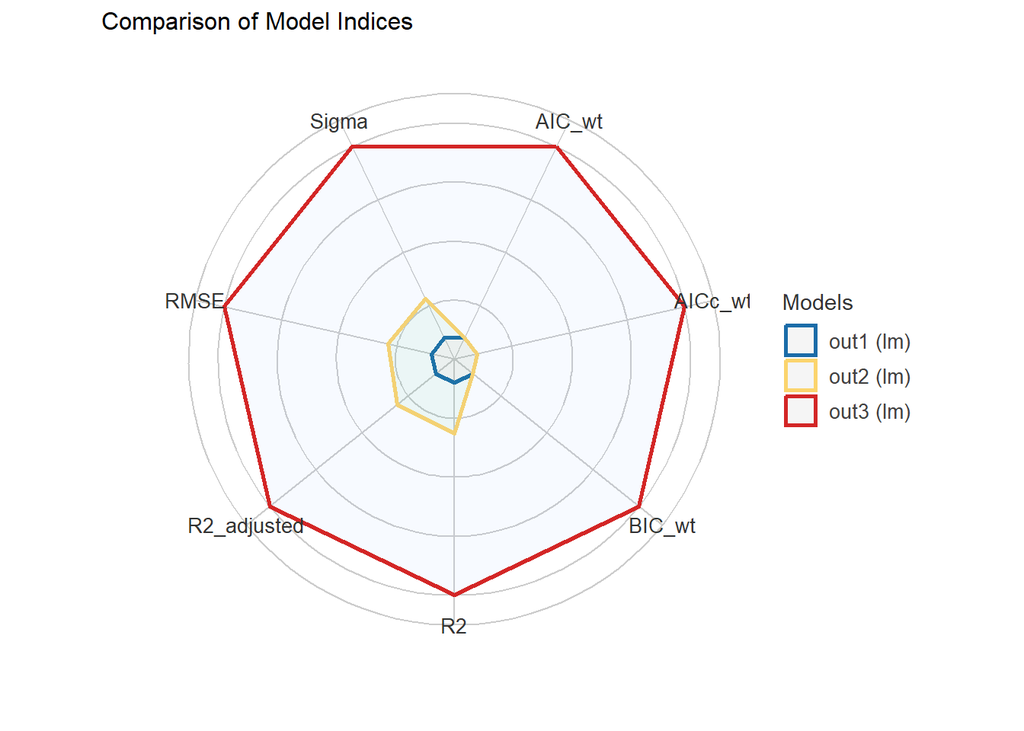

```r
plot(compare_performance(out1, out2, out3))
```

The `test_performance()` function carries out the most relevant and appropriate tests based on the input (for instance, whether the models are nested or not).

```r
test_performance(out1, out2, out3)
```

```
## Name | Model |     BF | Omega2 | p (Omega2) |     LR | p (LR)
## -------------------------------------------------------------
## out1 |    lm |        |        |            |        |
## out2 |    lm | > 1000 |   0.13 |     < .001 |  25.13 | < .001
## out3 |    lm | > 1000 |   0.41 |     < .001 | 111.90 | < .001
## Models were detected as nested (in terms of fixed parameters) and are compared in sequential order.
```

*[Note]* Omega squared is a measure of effect size. It is an estimate of how much variance in the outcome variable are accounted for by the predictor variables.

BF (Bayes factor) is the ratio of two competing models (two marginal likelihoods), and is used to quantify the support for one model over the other. A value of *K* > 1 means that current model is more strongly supported by the data than the previous model. According to Kass and Paftery (1995), 1 to 3.2 (not worth more than a bare mention), 3.2 to 10 (substantial), 10 to 100 (strong), > 100 (decisive).

## 4. Independent t-test

### Data

- **ChatGPT.sav**
- A psychologist is investigating people’s perspectives on using ChatGPT in their workplace.
- She recruited 24 participants and asked whether they have ever utilized ChatGPT.
- She also evaluated their stance on using ChatGPT in a work setting.
- The data has one column for ChatGPT usage experience (Use: 0 = No, 1 = Yes) and another for the attitude toward using ChatGPT in the workplace (Attitude: 0 [negative] to 10 [positive]).

```r
### Read the SPSS data
ChatGPT <- read_spss(file = 'ChatGPT.sav')
head(ChatGPT)
```

### Run Tests and Interpret Results

The `leveneTest()` from the `{car}` package conducts Levene’s test for homogeneity of variance.

```r
# install.packages("car")
library(car)
```

Before running the test, confirm that the Use variable is defined as a factor. In case it is not, convert the variable into a factor using the `as.factor()` function.

```r
ChatGPT$Use <- as.factor(ChatGPT$Use)
str(ChatGPT)
```

```
## tibble [24 × 2] (S3: tbl_df/tbl/data.frame)
##  $ Use     : Factor w/ 2 levels "0","1": 1 1 1 1 1 1 1 1 1 1 ...
##  $ Attitude: num [1:24] 3 1 5 4 6 4 6 2 0 5 ...
##   ..- attr(*, "label")= chr "Attitude toward ChatGPT"
##   ..- attr(*, "format.spss")= chr "F8.0"
```

```r
leveneTest(Attitude ~ Use, data = ChatGPT)
```

```
## Levene's Test for Homogeneity of Variance (center = median)
##       Df F value Pr(>F)
## group  1  0.2698 0.6087
##       22
```

We can also visually inspect the variances (i.e., distributions) using a boxplot.

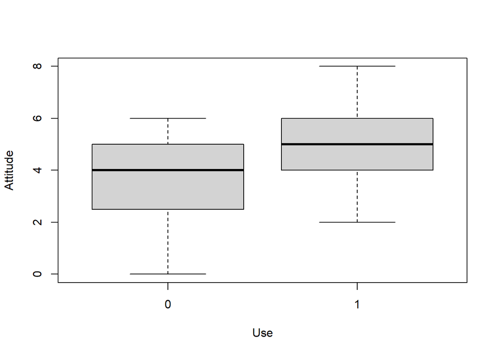

```r
plot(Attitude ~ Use, data = ChatGPT)
```

Now, let’s run t-test. R provides a built-in function, `t.test()`, which can be used for one-sample, independent, and paired t-tests.

```r
out1 <- t.test(Attitude ~ Use, data = ChatGPT, paired = FALSE, var.equal = TRUE)
out1
```

```
##
##  Two Sample t-test
##
## data:  Attitude by Use
## t = -1.7135, df = 22, p-value = 0.1007
## alternative hypothesis: true difference in means between group 0 and group 1 is not equal to 0
## 95 percent confidence interval:
##  -2.7629284  0.2629284
## sample estimates:
## mean in group 0 mean in group 1
##            3.75            5.00
```

```r
report(out1)
```

```
## Effect sizes were labelled following Cohen's (1988) recommendations.
##
## The Two Sample t-test testing the difference of Attitude by Use (mean in group
## 0 = 3.75, mean in group 1 = 5.00) suggests that the effect is negative,
## statistically not significant, and medium (difference = -1.25, 95% CI [-2.76,
## 0.26], t(22) = -1.71, p = 0.101; Cohen's d = -0.73, 95% CI [-1.59, 0.14])
```

*[Note]* If the data exhibits ‘unequal’ variances (indicated by a significant result from Levene’s test), modify the code with the argument `var.equal = FALSE`. This will call for conducting **Welch’s *t*-test**, which compares the means of two samples with unequal variances.

## 5. Paired t-test

### Data

- **ChatGPT-RM.sav**
- The psychologist instructed the 12 participants who had never used ChatGPT to utilize the tool for a week. Following this period, she re-evaluated their attitude toward using ChatGPT in the workplace, employing a pre-post design.
- The Data View window displays two columns: the attitude toward using ChatGPT, measured before use (Pre) and after use (Post).

```r
### Read the SPSS data
ChatGPTRM <- read_spss(file = 'ChatGPT RM.sav')
head(ChatGPTRM)
```

### Run Tests and Interpret Results

The `t.test()` function, when used with the argument `paired = TRUE`, performs paired t-test.

```r
out1 <- t.test(ChatGPTRM$Pre, ChatGPTRM$Post, paired = TRUE)
out1
```

```
##
##  Paired t-test
##
## data:  ChatGPTRM$Pre and ChatGPTRM$Post
## t = -3.8044, df = 11, p-value = 0.002921
## alternative hypothesis: true mean difference is not equal to 0
## 95 percent confidence interval:
##  -1.9731653 -0.5268347
## sample estimates:
## mean difference
##           -1.25
```

```r
report(out1)
```

```
## For paired samples, 'repeated_measures_d()' provides more options.
```

```
## Effect sizes were labelled following Cohen's (1988) recommendations.
##
## The Paired t-test testing the difference between ChatGPTRM$Pre and
## ChatGPTRM$Post (mean difference = -1.25) suggests that the effect is negative,
## statistically significant, and large (difference = -1.25, 95% CI [-1.97,
## -0.53], t(11) = -3.80, p = 0.003; Cohen's d = -1.10, 95% CI [-1.81, -0.36])
```

## 6. Analysis of Variance (ANOVA)

### Data

```r
### Read the SPSS data
BeerGoggles <- read_spss(file = 'Beer Goggles.sav')
head(BeerGoggles)
```

### Fit Models and Interpret Results

The `aov()` function is commonly employed for conducting ANOVA.

```r
out1 <- aov(Attractiveness ~ Gender + Alcohol + Gender*Alcohol, data = BeerGoggles)
summary(out1)
```

```
##                Df Sum Sq Mean Sq F value    Pr(>F)
## Gender          1    169   168.8    1.53  0.222658
## Alcohol         1   2363  2363.3   21.43 0.0000325 ***
## Gender:Alcohol  1   1582  1582.0   14.35  0.000458 ***
## Residuals      44   4853   110.3
## ---
## Signif. codes:  0 '***' 0.001 '**' 0.01 '*' 0.05 '.' 0.1 ' ' 1
```

```r
out1$coefficients
```

```
##    (Intercept)         Gender        Alcohol Gender:Alcohol
##       12.29167       24.37500       15.62500      -14.06250
```

```r
report(out1)
```

```
## The ANOVA (formula: Attractiveness ~ Gender + Alcohol + Gender * Alcohol)
## suggests that:
##
##   - The main effect of Gender is statistically not significant and small (F(1,
## 44) = 1.53, p = 0.223; Eta2 (partial) = 0.03, 95% CI [0.00, 1.00])
##   - The main effect of Alcohol is statistically significant and large (F(1, 44) =
## 21.43, p < .001; Eta2 (partial) = 0.33, 95% CI [0.15, 1.00])
##   - The interaction between Gender and Alcohol is statistically significant and
## large (F(1, 44) = 14.34, p < .001; Eta2 (partial) = 0.25, 95% CI [0.08, 1.00])
##
## Effect sizes were labelled following Field's (2013) recommendations.
```

The `pairewise.t.test()` function conducts post-hoc ‘pairwise’ comparisons while accounting for multiple testing.

```r
pairwise.t.test(BeerGoggles$Attractiveness, BeerGoggles$Alcohol, p.adjust.method = "bonf")
```

```
##
##  Pairwise comparisons using t tests with pooled SD
##
## data:  BeerGoggles$Attractiveness and BeerGoggles$Alcohol
##
##   1       2
## 2 1.00000 -
## 3 0.00024 0.00011
##
## P value adjustment method: bonferroni
```

### Check Model Assumptions and Performance

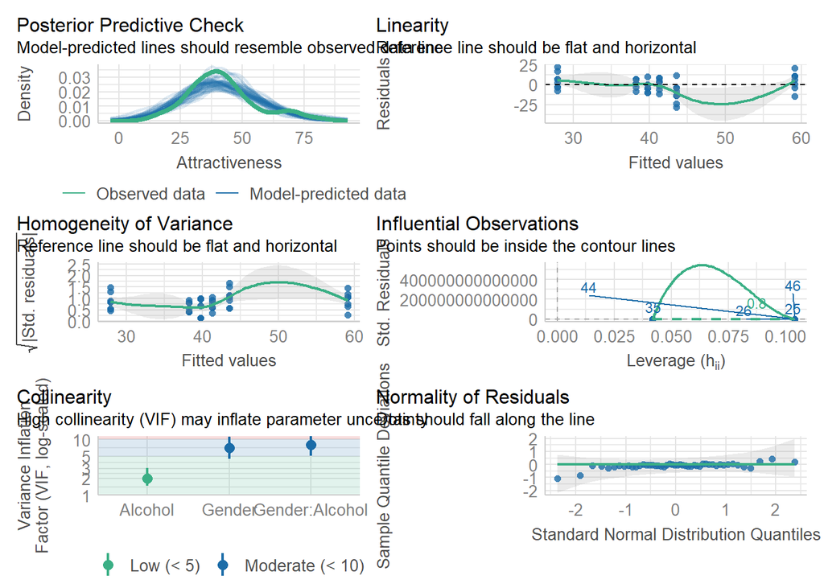

```r
check_model(out1)
```

```r
check_heteroscedasticity(out1)
```

```
## OK: Error variance appears to be homoscedastic (p = 0.430).
```

```r
model_performance(out1)
```

```
## # Indices of model performance
##
## AIC     |    AICc |     BIC |    R2 | R2 (adj.) |   RMSE |  Sigma
## -----------------------------------------------------------------
## 367.789 | 369.218 | 377.145 | 0.459 |     0.422 | 10.055 | 10.502
```

### Plot Data

The `{ggplot2}` package offers a powerful graphics language for producing elegant and complex plots. Its popularity in the R community has exploded in recent years.

```r
# install.packages("ggplot2")
library(ggplot2)
```

Before creating a graph, confirm that the Alcohol and Gender variables are defined as factors. In case they are not, convert them into factors using the `as.factor()` function.

```r
BeerGoggles$Alcohol <- as.factor(BeerGoggles$Alcohol)
BeerGoggles$Gender <- as.factor(BeerGoggles$Gender)
str(BeerGoggles)
```

```
## tibble [48 × 3] (S3: tbl_df/tbl/data.frame)
##  $ Gender        : Factor w/ 2 levels "0","1": 2 2 2 2 2 2 2 2 2 2 ...
##  $ Alcohol       : Factor w/ 3 levels "1","2","3": 1 1 1 1 1 1 1 1 2 2 ...
##  $ Attractiveness: num [1:48] 35 30 40 40 40 45 40 45 30 35 ...
##   ..- attr(*, "label")= chr "Attractiveness of Date"
##   ..- attr(*, "format.spss")= chr "F8.0"
##   ..- attr(*, "display_width")= int 13
```

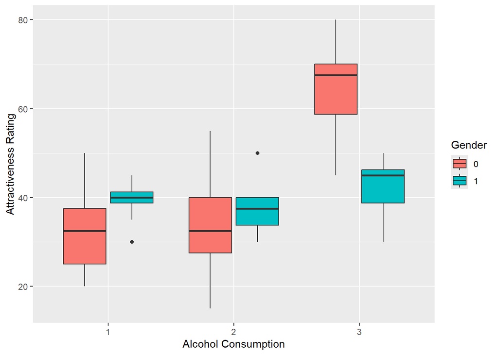

```r
ggplot(data = BeerGoggles, aes(x = Alcohol, y = Attractiveness)) +
  geom_boxplot(aes(fill = Gender)) +
  labs(x = "Alcohol Consumption",
       y = "Attractiveness Rating")
```

## 7. Repeated Measures Analysis of Variance (RM ANOVA)

### Data

- **Course Modality.sav**
- An instructor is interested in understanding students’ preference for course modes of course delivery. He provided four modules of a Survey Research course to eight graduate students.
- Each of these four modules was presented in a different mode of delivery (one mode per module): face-to-face, synchronous online, asynchronous online, and a combination of face-to-face and asynchronous online. At the end of each module, students rated their satisfaction with the module in a scale of 1 to 10 (1 = very unsatisfactory, 10 = very satisfactory).
- In this context, the mode of course delivery is the independent variable, while the students’ preference is repeated measures, dependent variable. The Data View window displays four columns corresponding to the four different course delivery modes: f2f, online_syn, online_asyn, f2f_online.

```r
### Read the SPSS data
CourseModality <- read_spss(file = 'Course Modality.sav')
head(CourseModality)
```

For data preparation, we need to do two things: (1) add an ID variable and (2) transform the data shape from ‘wide’ to a ‘long’ format.

The `{tidyr}` package, which is part of `tidyverse()`, offers two functions that can assist in achieving this:

- `pivot_wider()`: Reshape data from long to wide format.
- `pivot_longer()`: Reshape data from wide to long format.

```r
# install.packages(c("tidyverse", "rstatix"))
library(tidyverse)
library(rstatix)
```

```r
CourseModality_long <- CourseModality %>%
  mutate(ID = row_number()) %>% ### Add an ID variable
  pivot_longer(cols = c(f2f, online_syn, online_asyn, f2f_online), ### Reshaping
               names_to = "Modality",
               values_to = "Score") %>%
  convert_as_factor(ID, Modality) ### Convert numeric variables into character: function from the rstatix package

head(CourseModality_long)
```

```
## # A tibble: 6 × 3
##   ID    Modality    Score
##   <fct> <fct>       <dbl>
## 1 1     f2f             8
## 2 1     online_syn      7
## 3 1     online_asyn     1
## 4 1     f2f_online      6
## 5 2     f2f             9
## 6 2     online_syn      5
```

### Fit Models and Interpret Results

```r
out1 <- aov(Score ~ Modality + Error(ID/Modality), data = CourseModality_long)
summary(out1)
```

```
##
## Error: ID
##           Df Sum Sq Mean Sq F value Pr(>F)
## Residuals  7  17.38   2.482
##
## Error: ID:Modality
##           Df Sum Sq Mean Sq F value Pr(>F)
## Modality   3  83.12  27.708   3.794 0.0256 *
## Residuals 21 153.38   7.304
## ---
## Signif. codes:  0 '***' 0.001 '**' 0.01 '*' 0.05 '.' 0.1 ' ' 1
```

```r
report(out1)
```

```
## The repeated-measures ANOVA (formula: Score ~ Modality + Error(ID/Modality))
## suggests that:
##
##   - The main effect of Modality is statistically NA and large (F() = , ; Eta2
## (partial) = 0.35, 95% CI [0.03, 1.00])
##
## Effect sizes were labelled following Field's (2013) recommendations.
```

```r
pairwise.t.test(CourseModality_long$Score, CourseModality_long$Modality, paired = TRUE, p.adjust.method = "bonf")
```

```
##
##  Pairwise comparisons using paired t tests
##
## data:  CourseModality_long$Score and CourseModality_long$Modality
##
##             f2f    f2f_online online_asyn
## f2f_online  1.0000 -          -
## online_asyn 0.0056 1.0000     -
## online_syn  0.0121 1.0000     1.0000
##
## P value adjustment method: bonferroni
```

### Plot Data

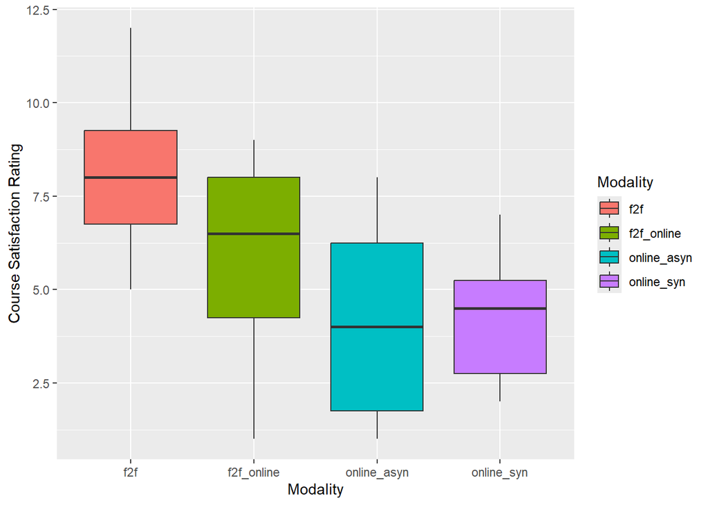

```r
ggplot(data = CourseModality_long, aes(x = Modality, y = Score)) +
  geom_boxplot(aes(fill = Modality)) +
  labs(x = "Modality",
       y = "Course Satisfaction Rating")
```

## 8. Mixed Analysis of Variance (Mixed ANOVA)

### Data

- **Teaching Eval.sav**
- Three math teachers were assessed by six principals and six peer educators for their teaching effectiveness. Both the principals and peers observed the classroom teaching and completed a Teaching Effectiveness Scale, rating the teachers in terms of planning, instruction, learning environment, and professional practices and responsibilities on a scale of 0 to 10 (0 = very ineffective, 10 = very effective).
- In this context, the independent variables are (1) the teacher being evaluated (Teacher 1, 2, or 3) and (2) whether the evaluator was a principal or peer. The evaluator’s rating of teaching effectiveness is repeated measures, dependent variable.
- The data has three columns, each corresponding to one of the three teachers: Teacher1, Teacher2, Teacher3. The Rater column indicates whether the evaluator was a principal or peer educator (1 = Principal, 2 = Peer; between-group variable).

```r
### Read the SPSS data
TeachingEval <- read_spss(file = 'Teaching Eval.sav')
head(TeachingEval)
```

For data preparation, we need to do two things: (1) add an ID variable and (2) transform the data shape from ‘wide’ to a ‘long’ format.

```r
TeachingEval_long <- TeachingEval %>%
  mutate(ID = row_number()) %>% ### Add an ID variable
  pivot_longer(cols = Teacher1:Teacher3, ### Reshaping
               names_to = "Teacher",
               values_to = "Score") %>%
  convert_as_factor(ID, Teacher, Rater) ### Convert numeric variables into character

head(TeachingEval_long)
```

```
## # A tibble: 6 × 4
##   Rater ID    Teacher  Score
##   <fct> <fct> <fct>    <dbl>
## 1 1     1     Teacher1     1
## 2 1     1     Teacher2     3
## 3 1     1     Teacher3     1
## 4 1     2     Teacher1     2
## 5 1     2     Teacher2     5
## 6 1     2     Teacher3     3
```

### Fit Models and Interpret Results

```r
out1 <- aov(Score ~ Rater + Teacher + Rater*Teacher + Error(ID/Teacher), data = TeachingEval_long)
summary(out1)
```

```
##
## Error: ID
##           Df Sum Sq Mean Sq F value Pr(>F)
## Rater      1   2.25   2.250   0.511  0.491
## Residuals 10  44.06   4.406
##
## Error: ID:Teacher
##               Df Sum Sq Mean Sq F value      Pr(>F)
## Teacher        2 174.06   87.03  36.946 0.000000192 ***
## Rater:Teacher  2  18.17    9.08   3.856      0.0383 *
## Residuals     20  47.11    2.36
## ---
## Signif. codes:  0 '***' 0.001 '**' 0.01 '*' 0.05 '.' 0.1 ' ' 1
```

```r
report(out1)
```

```
## The repeated-measures ANOVA (formula: Score ~ Rater + Teacher + Rater * Teacher
## + Error(ID/Teacher)) suggests that:
##
##   - The main effect of Rater is statistically NA and small (F() = , ; Eta2
## (partial) = 0.05, 95% CI [0.00, 1.00])
##   - The interaction between Rater and Teacher is statistically NA and large (F()
## = , ; Eta2 (partial) = 0.79, 95% CI [0.62, 1.00])
##   - The main effect of Teacher is statistically NA and large (F() = , ; Eta2
## (partial) = 0.28, 95% CI [0.01, 1.00])
##
## Effect sizes were labelled following Field's (2013) recommendations.
```

```r
pairwise.t.test(TeachingEval_long$Score, TeachingEval_long$Teacher, paired = TRUE, p.adjust.method = "bonf")
```

```
##
##  Pairwise comparisons using paired t tests
##
## data:  TeachingEval_long$Score and TeachingEval_long$Teacher
##
##          Teacher1 Teacher2
## Teacher2 0.00026  -
## Teacher3 0.39746  0.00017
##
## P value adjustment method: bonferroni
```

The `{lme4}` package is extensively utilized for mixed modeling. Unlike the `aov()` function, this package is also compatible with the `{performance}` packages.

```r
# install.packages("lme4")
library(lme4)
```

```r
out2 <- lmer(Score ~ Rater + Teacher + Rater*Teacher + (1 | ID), REML = TRUE, data = TeachingEval_long)
summary(out2)
```

```
## Linear mixed model fit by REML ['lmerMod']
## Formula: Score ~ Rater + Teacher + Rater * Teacher + (1 | ID)
##    Data: TeachingEval_long
##
## REML criterion at convergence: 127.9
##
## Scaled residuals:
##      Min       1Q   Median       3Q      Max
## -1.47155 -0.60657  0.01972  0.54817  1.68518
##
## Random effects:
##  Groups   Name        Variance Std.Dev.
##  ID       (Intercept) 0.6833   0.8266
##  Residual             2.3556   1.5348
## Number of obs: 36, groups:  ID, 12
##
## Fixed effects:
##                        Estimate Std. Error t value
## (Intercept)              3.8333     0.7117   5.386
## Rater2                  -0.3333     1.0065  -0.331
## TeacherTeacher2          2.6667     0.8861   3.009
## TeacherTeacher3         -0.8333     0.8861  -0.940
## Rater2:TeacherTeacher2   2.8333     1.2531   2.261
## Rater2:TeacherTeacher3  -0.3333     1.2531  -0.266
##
## Correlation of Fixed Effects:
##             (Intr) Rater2 TchrT2 TchrT3 R2:TT2
## Rater2      -0.707
## TeachrTchr2 -0.623  0.440
## TeachrTchr3 -0.623  0.440  0.500
## Rtr2:TchrT2  0.440 -0.623 -0.707 -0.354
## Rtr2:TchrT3  0.440 -0.623 -0.354 -0.707  0.500
```

```r
anova(out2)
```

```
## Analysis of Variance Table
##               npar  Sum Sq Mean Sq F value
## Rater            1   1.203   1.203  0.5107
## Teacher          2 174.056  87.028 36.9458
## Rater:Teacher    2  18.167   9.083  3.8561
```

```r
report(out2)
```

```
## We fitted a linear mixed model (estimated using REML and nloptwrap optimizer)
## to predict Score with Rater and Teacher (formula: Score ~ Rater + Teacher +
## Rater * Teacher). The model included ID as random effect (formula: ~1 | ID).
## The model's total explanatory power is substantial (conditional R2 = 0.73) and
## the part related to the fixed effects alone (marginal R2) is of 0.65. The
## model's intercept, corresponding to Rater = 1 and Teacher = Teacher1, is at
## 3.83 (95% CI [2.38, 5.29], t(28) = 5.39, p < .001). Within this model:
##
##   - The effect of Rater [2] is statistically non-significant and negative (beta =
## -0.33, 95% CI [-2.39, 1.73], t(28) = -0.33, p = 0.743; Std. beta = -0.12, 95%
## CI [-0.84, 0.60])
##   - The effect of Teacher [Teacher2] is statistically significant and positive
## (beta = 2.67, 95% CI [0.85, 4.48], t(28) = 3.01, p = 0.005; Std. beta = 0.93,
## 95% CI [0.30, 1.57])
##   - The effect of Teacher [Teacher3] is statistically non-significant and
## negative (beta = -0.83, 95% CI [-2.65, 0.98], t(28) = -0.94, p = 0.355; Std.
## beta = -0.29, 95% CI [-0.93, 0.34])
##   - The effect of Rater [2] × Teacher [Teacher2] is statistically significant and
## positive (beta = 2.83, 95% CI [0.27, 5.40], t(28) = 2.26, p = 0.032; Std. beta
## = 0.99, 95% CI [0.09, 1.89])
##   - The effect of Rater [2] × Teacher [Teacher3] is statistically non-significant
## and negative (beta = -0.33, 95% CI [-2.90, 2.23], t(28) = -0.27, p = 0.792;
## Std. beta = -0.12, 95% CI [-1.02, 0.78])
##
## Standardized parameters were obtained by fitting the model on a standardized
## version of the dataset. 95% Confidence Intervals (CIs) and p-values were
## computed using a Wald t-distribution approximation.
```

*[Note]* The **restricted maximum likelihood** (REML) procedure estimates fixed and random parameters (Raudenbush & Bryk, 2002; Searle, Casella & McCulloch, 1992). In cases where model comparison is not involved, the main difference between REML and **maximum likelihood** (ML) is that REML provides unbiased estimates of the variance parameters. However, it is important to note that when performing model comparison, REML cannot be used to compare model. This limitation arises from the fact that REML transforms the data, rendering the likelihood incomparable for such comparisons.

### Check Model Assumptions and Performance

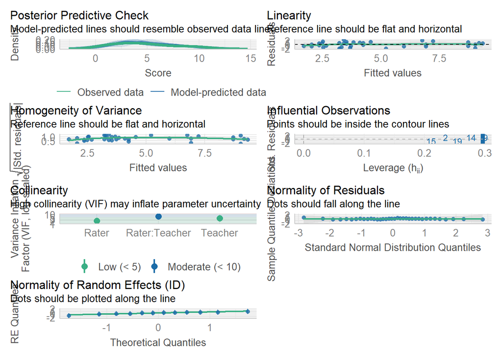

```r
check_model(out2)
```

```r
check_heteroscedasticity(out2)
```

```
## OK: Error variance appears to be homoscedastic (p = 0.965).
```

```r
model_performance(out2)
```

```
## # Indices of model performance
##
## AIC     |    AICc |     BIC | R2 (cond.) | R2 (marg.) |   ICC |  RMSE | Sigma
## -----------------------------------------------------------------------------
## 143.851 | 149.184 | 156.519 |      0.726 |      0.646 | 0.225 | 1.288 | 1.535
```

### Plot Data

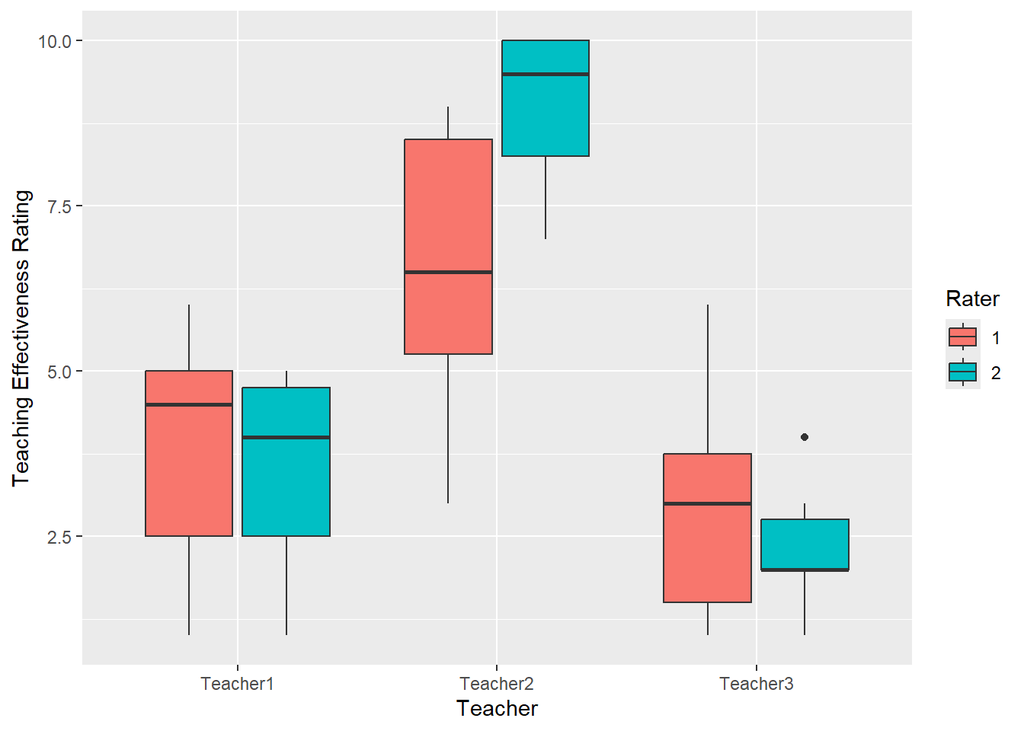

```r
ggplot(data = TeachingEval_long, aes(x = Teacher, y = Score)) +
  geom_boxplot(aes(fill = Rater)) +
  labs(x = "Teacher",
       y = "Teaching Effectiveness Rating")
```